# (Forbes Billionaires of 2021)

## Research question 2 : The richest man in the world and top 10?

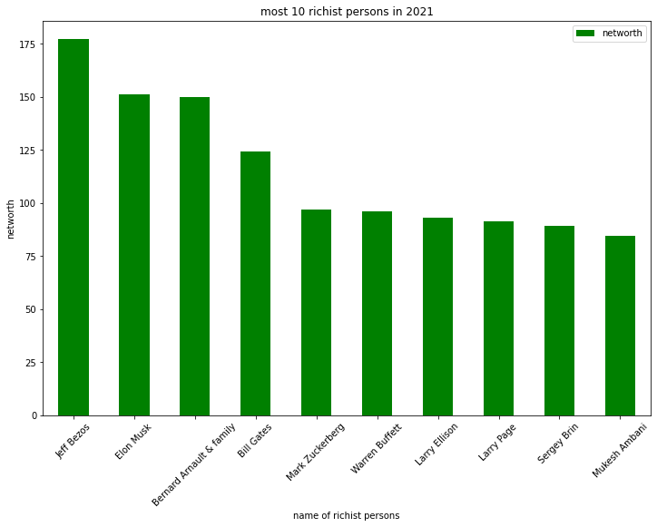

```python
df_clean.nlargest(10,'networth').plot.bar(x='name',y='networth',color='green',figsize=[12,8]);
plt.xticks(rotation=45);
plt.title('most 10 richist persons in 2021');
plt.xlabel('name of richist persons');
plt.ylabel('networth');
```

> the richest person in the world in 2021 is jeff bezos with 177 B then Elon Musk with 151 B ,Bernard Arnault with 150 B

## Research question 3 : The billionaires are the least wealthy?

```python
least_networht = df_clean.nsmallest(10,'networth').sort_values(by='networth',ascending=False)
least_networht
```

|  | name | networth | country | source | rank | age | industry |
| --- | --- | --- | --- | --- | --- | --- | --- |
| 2673 | A. Jayson Adair | 1.0 | United States | damaged cars | 2674 | 51.0 | Automotive |
| 2674 | Albert Avdolyan | 1.0 | Russia | oil, mining | 2674 | 50.0 | Energy |
| 2675 | Baiju Bhatt | 1.0 | United States | stock trading app | 2674 | 36.0 | Finance & Investments |
| 2676 | Wilbur 'Ed' Bosarge, Jr. | 1.0 | United States | high speed trading | 2674 | 81.0 | Finance & Investments |
| 2677 | Ina Chan | 1.0 | Hong Kong | casinos | 2674 | 67.0 | Gambling & Casinos |
| 2678 | Chang Byung-gyu | 1.0 | South Korea | Bluehole | 2674 | 47.0 | Technology |
| 2679 | Chung Mong-joon | 1.0 | South Korea | shipbuilding, industrial machines | 2674 | 69.0 | Manufacturing |
| 2680 | Carmen Daurella Aguilera | 1.0 | Spain | Coca-Cola bottler | 2674 | NaN | Food & Beverage |
| 2681 | GT Dave | 1.0 | United States | kombucha | 2674 | 44.0 | Food & Beverage |
| 2682 | Mukand Lal Dua | 1.0 | India | footwear | 2674 | 72.0 | Fashion & Retail |

> The lowest 10 people in terms of wealth all share the same wealth and hence the same rank ->2674

## Research question 4 : The country has billions more?

```python
top_country = df_clean.groupby("country").networth.sum().sort_values(ascending= False).head(20).to_frame().reset_index()
top_country
```

|  | country | networth |
| --- | --- | --- |
| 0 | United States | 4398.399902 |
| 1 | China | 2531.899902 |
| 2 | Germany | 625.500000 |
| 3 | India | 596.400024 |
| 4 | Russia | 586.000000 |
| 5 | France | 512.200012 |
| 6 | Hong Kong | 448.200012 |
| 7 | Canada | 231.100006 |
| 8 | Japan | 225.399994 |
| 9 | United Kingdom | 213.899994 |
| 10 | Brazil | 211.699997 |
| 11 | Italy | 204.500000 |
| 12 | Sweden | 182.000000 |
| 13 | Australia | 181.500000 |
| 14 | Singapore | 156.899994 |
| 15 | Switzerland | 145.500000 |
| 16 | Spain | 137.000000 |
| 17 | Mexico | 136.100006 |
| 18 | South Korea | 121.400002 |
| 19 | Taiwan | 115.599998 |

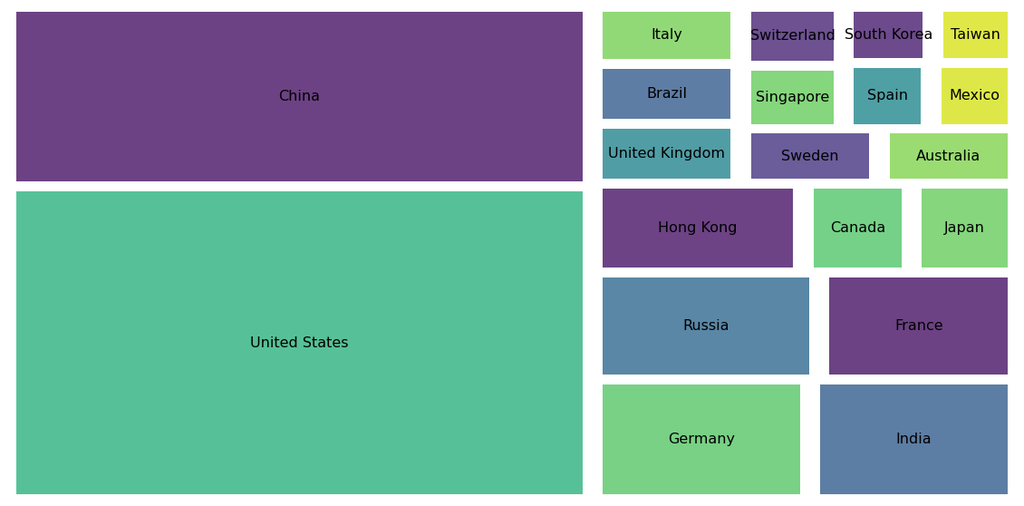

```python
plt.figure(figsize=[20,10])

squarify.plot(top_country['networth'],value=top_country['country'],alpha=0.8,pad=True,text_kwargs={'size':'16'});
plt.axis('off');
```

> united states has over 4 T dollar then china with over 2 T dollar,Germany with 625 billion dollar

## Research question 5 : The country has the most billionaires?

```python
top_coun_billioners = df_clean['country'].value_counts().rename_axis('country').head(20).reset_index(name='counts')
top_coun_billioners
```

|  | country | counts |
| --- | --- | --- |
| 0 | United States | 724 |
| 1 | China | 626 |
| 2 | India | 140 |
| 3 | Germany | 136 |
| 4 | Russia | 118 |
| 5 | Hong Kong | 71 |
| 6 | Brazil | 65 |
| 7 | Canada | 64 |
| 8 | United Kingdom | 56 |
| 9 | Italy | 51 |
| 10 | Japan | 49 |
| 11 | Taiwan | 47 |
| 12 | Australia | 44 |
| 13 | South Korea | 43 |
| 14 | France | 42 |
| 15 | Sweden | 41 |
| 16 | Switzerland | 40 |
| 17 | Thailand | 31 |
| 18 | Spain | 30 |
| 19 | Singapore | 27 |

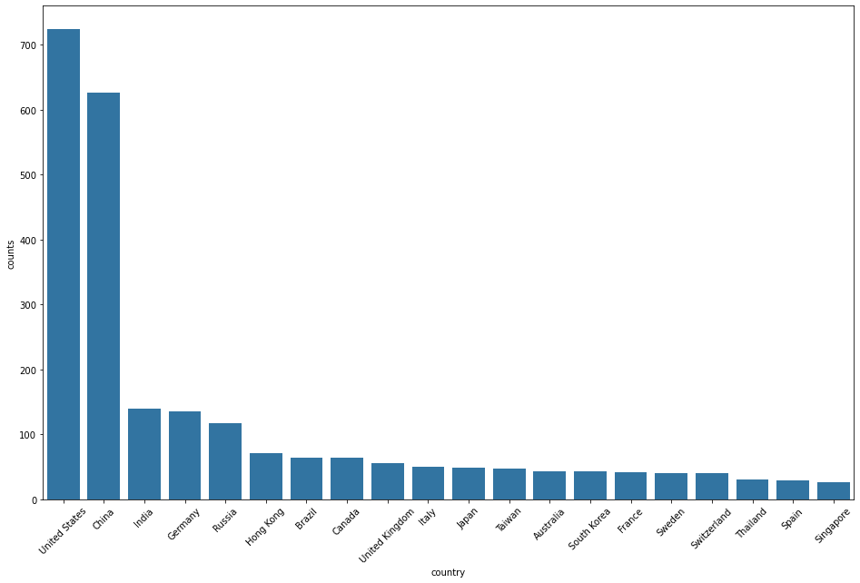

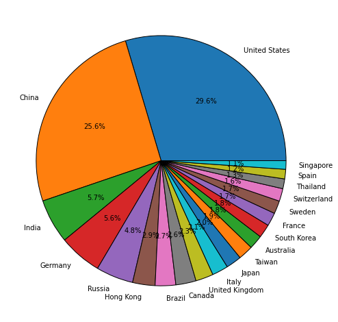

```python
# plot on top
plt.figure(figsize=[16,10])
base_color = sb.color_palette()[0]
plt.subplot(1,1,1);
sb.barplot(data=top_coun_billioners,x='country',y='counts',color=base_color);
plt.xticks(rotation=45);

# plot on bottom
plt.figure(figsize=[18,10])
plt.subplot(1,2,2);
labels = top_coun_billioners.country
countrys = top_coun_billioners.counts
plt.pie(data=top_coun_billioners,x=countrys,labels=labels,wedgeprops={'edgecolor':'black'},autopct='%1.1f%%');
```

> the country with has most person called billioner is untited states with 724 persons then china with 626 persons , india 140 persons

## Research question 6 : Which industries do billionaires invest in most?

```python
top_ind_billioner = df_clean['industry'].value_counts().rename_axis('industry').head(20).reset_index(name='counts')
top_ind_billioner
```

|  | industry | counts |
| --- | --- | --- |
| 0 | Finance & Investments | 371 |
| 1 | Technology | 365 |
| 2 | Manufacturing | 331 |
| 3 | Fashion & Retail | 273 |
| 4 | Healthcare | 221 |
| 5 | Food & Beverage | 219 |
| 6 | Real Estate | 215 |
| 7 | Diversified | 188 |
| 8 | Energy | 100 |
| 9 | Media & Entertainment | 95 |
| 10 | Service | 75 |
| 11 | Metals & Mining | 74 |
| 12 | Automotive | 68 |
| 13 | Construction & Engineering | 44 |
| 14 | Logistics | 35 |
| 15 | Telecom | 32 |
| 16 | Gambling & Casinos | 25 |
| 17 | Sports | 24 |

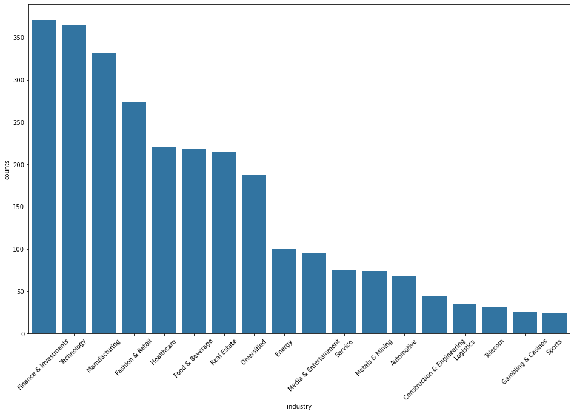

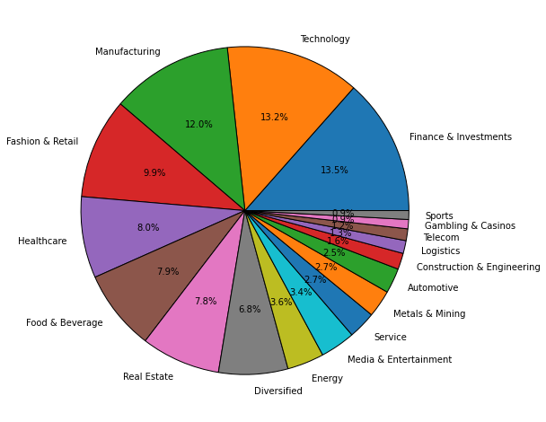

```python
plt.figure(figsize=[16,10])
base_color = sb.color_palette()[0]
plt.subplot(1,1,1);
sb.barplot(data=top_ind_billioner,x='industry',y='counts',color=base_color);
plt.xticks(rotation=45);

# plot on bottom
plt.figure(figsize=[18,10])
plt.subplot(1,2,2);
labels = top_ind_billioner.industry
ind = top_ind_billioner.counts
plt.pie(data=top_ind_billioner,x=ind,labels=labels,wedgeprops={'edgecolor':'black'},autopct='%1.1f%%');
```

> from two figures above It appears that the largest industry in which the rich invest is finance & invest with 371 people, then technology comes with 365 people, then a third is manufacturing with 331 people.

## Research question 7 : industries that contribute the most to the total value?

```python
top_industry = df_clean.groupby('industry').networth.sum().sort_values(ascending= False).to_frame().reset_index()
top_industry
```

|  | industry | networth |
| --- | --- | --- |
| 0 | Technology | 2456.699951 |
| 1 | Fashion & Retail | 1697.599976 |
| 2 | Finance & Investments | 1527.900024 |
| 3 | Manufacturing | 1119.900024 |
| 4 | Food & Beverage | 1029.900024 |
| 5 | Diversified | 868.100037 |
| 6 | Real Estate | 815.799988 |
| 7 | Healthcare | 790.700012 |
| 8 | Media & Entertainment | 481.299988 |
| 9 | Automotive | 467.500000 |
| 10 | Energy | 452.600006 |
| 11 | Metals & Mining | 431.399994 |
| 12 | Service | 248.699997 |
| 13 | Telecom | 209.399994 |
| 14 | Logistics | 145.800003 |
| 15 | Gambling & Casinos | 134.000000 |
| 16 | Construction & Engineering | 125.099998 |
| 17 | Sports | 81.699997 |

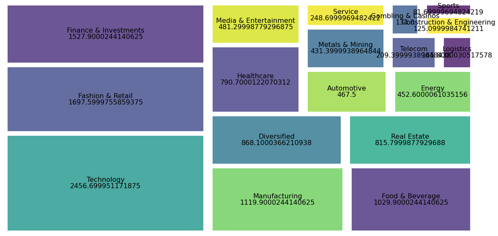

```python
plt.figure(figsize=[20,10])
net = top_industry['networth']

squarify.plot(sizes=top_industry['networth'],label=top_industry['industry'],alpha=0.8,pad=True,text_kwargs={'size':'16'},value=top_industry['networth']);
plt.axis('off');
```

[output not shown]

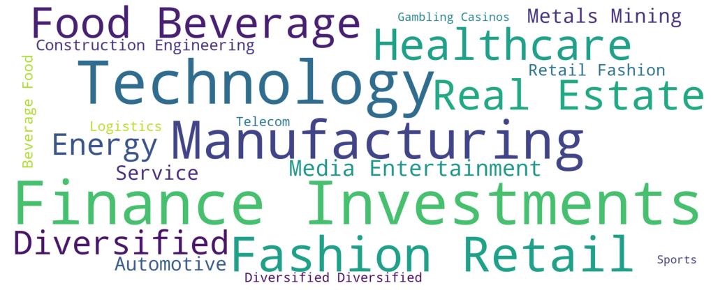

```python
plt.figure(figsize=[18,10])
word =  " ".join(df_clean["industry"]);
indus = WordCloud(width = 2000, height = 800, background_color ="white",min_font_size = 10).generate(word);
plt.imshow(indus);
plt.axis('off')
```

> We conclude that the most money-making industry is technology with over 2 T then fashion with 1.69 T dollar then finance with 1.5 T dollar,etc..

## Research question 9 : Which source do billionaires invest in most?

```python
top_source_billioner = df_clean['source'].value_counts().rename_axis('source').head(20).reset_index(name='counts')
top_source_billioner
```

|  | source | counts |
| --- | --- | --- |
| 0 | real estate | 171 |
| 1 | pharmaceuticals | 99 |
| 2 | investments | 90 |
| 3 | diversified | 85 |
| 4 | software | 62 |
| 5 | retail | 47 |
| 6 | hedge funds | 42 |
| 7 | private equity | 35 |
| 8 | chemicals | 32 |
| 9 | consumer goods | 32 |
| 10 | banking | 29 |
| 11 | manufacturing | 27 |
| 12 | e-commerce | 24 |
| 13 | electronics | 23 |
| 14 | education | 21 |
| 15 | mining | 20 |
| 16 | finance | 20 |
| 17 | auto parts | 18 |
| 18 | telecom | 18 |
| 19 | medical devices | 17 |

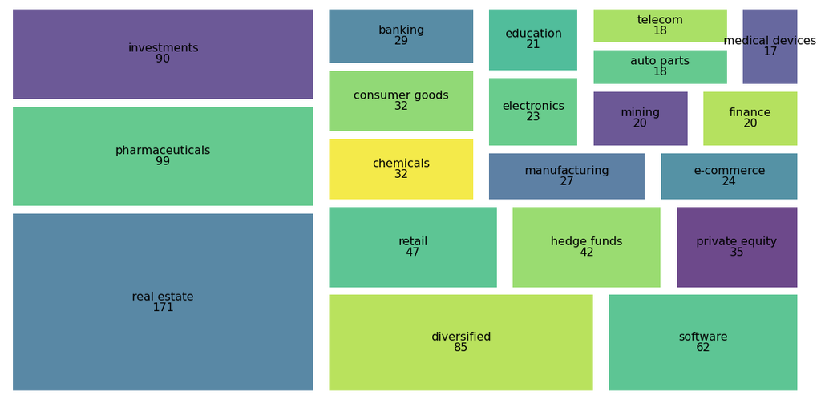

```python
plt.figure(figsize=[20,10])

squarify.plot(sizes=top_source_billioner['counts'],label=top_source_billioner['source'],alpha=0.8,pad=True,text_kwargs={'size':'16'},value=top_source_billioner['counts']);
plt.axis('off');
```

## Research question 8 : what is the relationship between age and networth?

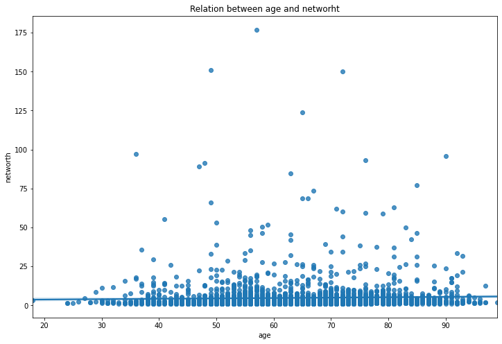

```python
plt.figure(figsize=[12,8])
sb.regplot(data=df_clean,x='age',y='networth');
plt.xlabel('age')
plt.ylabel('networth')
plt.title('Relation between age and networht');
```

> From the above figure, it is clear that the number of people between the ages of 40 and 80 have the most wealth, and we can conclude that the richest people in the world are between this age group.

```python
df_clean.head(2)
```

|  | name | networth | country | source | rank | age | industry |
| --- | --- | --- | --- | --- | --- | --- | --- |
| 0 | Jeff Bezos | 177.0 | United States | Amazon | 1 | 57.0 | Technology |
| 1 | Elon Musk | 151.0 | United States | Tesla, SpaceX | 2 | 49.0 | Automotive |

```python
df_clean.loc[:,['country','industry']]
```

|  | country | industry |
| --- | --- | --- |
| 0 | United States | Technology |
| 1 | United States | Automotive |
| 2 | France | Fashion & Retail |
| 3 | United States | Technology |
| 4 | United States | Technology |
| 5 | United States | Finance & Investments |
| 6 | United States | Technology |
| 7 | United States | Technology |
| 8 | United States | Technology |
| 9 | India | Diversified |
| 10 | Spain | Fashion & Retail |
| 11 | France | Fashion & Retail |
| 12 | China | Food & Beverage |
| 13 | United States | Technology |
| 14 | China | Technology |
| 15 | Mexico | Telecom |
| 16 | United States | Fashion & Retail |
| 17 | United States | Fashion & Retail |
| 18 | United States | Fashion & Retail |
| 19 | United States | Media & Entertainment |
| 20 | China | Technology |
| 21 | United States | Technology |
| 22 | United States | Finance & Investments |
| 23 | India | Diversified |
| 24 | United States | Fashion & Retail |
| 25 | China | Technology |
| 26 | United States | Diversified |
| 27 | United States | Diversified |
| 28 | Japan | Telecom |
| 29 | United States | Technology |

[output cut: 2725 more lines]

```python
df_clean['industry'].value_counts()
```

```
Finance & Investments         371
Technology                    365
Manufacturing                 331
Fashion & Retail              273
Healthcare                    221
Food & Beverage               219
Real Estate                   215
Diversified                   188
Energy                        100
Media & Entertainment          95
Service                        75
Metals & Mining                74
Automotive                     68
Construction & Engineering     44
Logistics                      35
Telecom                        32
Gambling & Casinos             25
Sports                         24
Name: industry, dtype: int64
```

## The most featured Country distributions of top 4 industry

```python
Finance_Investments = df_clean[df_clean["industry"]=="Finance & Investments"]
Finance_Investments =  Finance_Investments["country"].value_counts().head()

Technology = df_clean[df_clean["industry"]=="Technology"]
Technology = Technology["country"].value_counts().head()

Manufacturing  = df_clean[df_clean["industry"]=="Manufacturing"]
Manufacturing = Manufacturing["country"].value_counts().head()

Fashion_Retail = df_clean[df_clean["industry"]=="Fashion & Retail"]
Fashion_Retail = Fashion_Retail["country"].value_counts().head()
```

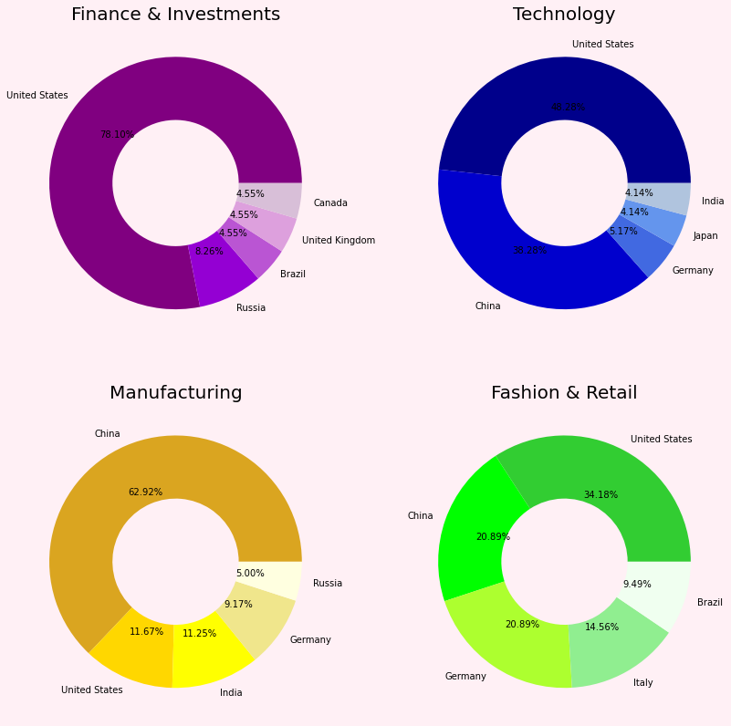

```python
fig = plt.figure(figsize=(14,14))
fig.set_facecolor('lavenderblush')

colors1 = ["purple", "darkviolet", "mediumorchid", "plum", "thistle"]
colors2 = ["darkblue", "mediumblue", "royalblue", "cornflowerblue", "lightsteelblue"]
colors3 = ["goldenrod", "gold", "yellow", "khaki", "lightyellow"]
colors4 = ["limegreen", "lime", "greenyellow", "lightgreen", "honeydew"]

ax1 = fig.add_subplot(221)
pie1 = ax1.pie(labels = Finance_Investments.index, x=Finance_Investments, colors = colors1,
       autopct=lambda p : '{:.2f}%'.format(p),wedgeprops=dict(width=0.5))
ax2 = fig.add_subplot(222)
pie2 = ax2.pie(labels = Technology.index, x=Technology, colors = colors2,
       autopct=lambda p : '{:.2f}%'.format(p),wedgeprops=dict(width=0.5))
ax3 = fig.add_subplot(223)
pie3 = ax3.pie(labels = Manufacturing.index, x=Manufacturing, colors = colors3,
       autopct=lambda p : '{:.2f}%'.format(p),wedgeprops=dict(width=0.5))
ax4 = fig.add_subplot(224)
pie4 = ax4.pie(labels = Fashion_Retail.index, x=Fashion_Retail, colors = colors4,
       autopct=lambda p : '{:.2f}%'.format(p),wedgeprops=dict(width=0.5))

# subtitles
ax1.set_title("Finance & Investments", fontsize = 20)
ax2.set_title("Technology", fontsize = 20)
ax3.set_title("Manufacturing", fontsize = 20)
ax4.set_title("Fashion & Retail", fontsize = 20)
plt.show()
```

```python
df_clean['industry'].value_counts()
```

```
Finance & Investments         371
Technology                    365
Manufacturing                 331
Fashion & Retail              273
Healthcare                    221
Food & Beverage               219
Real Estate                   215
Diversified                   188
Energy                        100
Media & Entertainment          95
Service                        75
Metals & Mining                74
Automotive                     68
Construction & Engineering     44
Logistics                      35
Telecom                        32
Gambling & Casinos             25
Sports                         24
Name: industry, dtype: int64
```

> in top four industries :
> 1. finance & Investment : The United States of America has the largest number of millionaires who own their wealth from investing in finance & investment, followed by Russia, Brazil, the United Kingdom and Canada in very close proportions.
> 2. Technology : America also has the largest number of millionaires who own their wealth from investing in technology, then China comes in second place, then Germany in third place, then Japan and India with almost the same percentage
> 3. Manufacturing : China has the largest number of millionaires who own their wealth from investing in manufacturing, then America comes in second place, then India in third, then Germany and Russia recently
> 4. Fashion & Retail : In this field, the United States of America also has the largest percentage of millionaires, followed by China, Germany, Italy and Brazil

> We conclude from this that the United States of America and China have the most number of millionaires who invest in the four industries most favored by millionaires.